# UK2007 Spam Detection Analysis

### ROC/AUC Comparison and Interpretation

The table above summarizes the predictive performance of each feature set and classification method using 5-fold cross-validated AUC as the main metric. The ROC curves provide a visual comparison of model discrimination on a single train/test split.

#### Ranking of Feature Sets by Predictive Power (AUC)

1. **Content-based Features** (AUC = 0.7878) — *Best predictive performance*
2. **Link-based Features** (AUC = 0.7345)
3. **Direct Features** (AUC = 0.5245) — *Poorest predictive performance*

#### Analysis and Comparison of Results

Based on the comprehensive metrics, we can analyze the performance of each feature set and classification method:

1. **Direct Features (Logistic Regression)**
   - *Performance Metrics*:
     - CV_AUC: 0.5245 (barely better than random)
     - Precision, Recall, F1: All 0.0000
   - *Strengths*:
     - Simple and interpretable model
     - Fast training and prediction
     - Works well with small feature sets
   - *Weaknesses*:
     - Severely underperforms in this spam detection task
     - Cannot capture complex patterns with only 2 features
     - Linear model limitations in handling non-linear relationships
   - *Context*: The poor performance suggests that basic host-level features (page count and domain length) are insufficient for spam detection.
2. **Link-based Features (Random Forest)**
   - *Performance Metrics*:
     - CV_AUC: 0.7345 (moderate performance)
     - Precision: 0.3542
     - Recall: 0.1589
     - F1: 0.2194
   - *Strengths*:
     - Handles high-dimensional data (138 features) effectively
     - Captures non-linear relationships and feature interactions
     - Robust to outliers and noise
     - Built-in feature importance evaluation
   - *Weaknesses*:
     - Low recall indicates missing many spam cases
     - Moderate precision suggests false positives
     - May be computationally intensive
   - *Context*: The link structure provides valuable information for spam detection, but the model struggles with class imbalance.
3. **Content-based Features (SVM with RBF)**
   - *Performance Metrics*:
     - CV_AUC: 0.7878 (best overall performance)
     - Precision: 0.2927
     - Recall: 0.3871
     - F1: 0.3333
   - *Strengths*:
     - Best overall performance in terms of CV_AUC
     - Highest recall among all models
     - Effective at capturing non-linear patterns in text
     - Good at handling medium-dimensional data (96 features)
   - *Weaknesses*:
     - Lower precision than link-based features
     - Sensitive to parameter tuning
     - Computationally intensive for large datasets
   - *Context*: Content features provide the most discriminative power for spam detection, with SVM effectively capturing textual patterns.

#### Discussion of Classification Methods in Context

1. **Logistic Regression**
   - *Suitability for Problem*: Not suitable for this spam detection task
   - *Reasoning*: The binary nature of spam detection requires capturing complex patterns that simple linear models cannot represent
   - *Recommendation*: Should be used only as a baseline or in combination with other features
2. **Random Forest**
   - *Suitability for Problem*: Well-suited for link-based features
   - *Reasoning*:
     - Handles the high dimensionality of link features
     - Can capture complex relationships in the link structure
     - Provides feature importance insights
   - *Recommendation*: Good choice for link-based analysis, but needs class imbalance handling
3. **SVM with RBF Kernel**
   - *Suitability for Problem*: Best performing for content-based features
   - *Reasoning*:
     - Effective at capturing non-linear patterns in text
     - Works well with standardized features
     - Good at handling the medium-dimensional content feature space
   - *Recommendation*: Optimal choice for content-based spam detection

#### Overall Findings and Recommendations

1. **Feature Set Importance**:
   - Content features are most discriminative (highest CV_AUC)
   - Link features provide complementary information
   - Direct features add little value alone
2. **Model Selection Strategy**:
   - Use SVM for content-based analysis
   - Use Random Forest for link-based analysis
   - Consider ensemble methods combining both approaches
3. **Class Imbalance Handling**:
   - All models show signs of struggling with class imbalance
   - Higher recall in content-based model suggests better handling of minority class
   - Consider additional techniques like SMOTE or class weights
4. **Practical Deployment Considerations**:
   - Content-based SVM provides best overall performance
   - Link-based Random Forest offers good precision
   - Consider computational costs in production environment

# 5. Feature Set Combinations: Model Deployment and Comparison

### 5.1 Combination 1: Obvious Features (Set 1) + Link-based Features (Set 2)

> We combined the obvious features and link-based features to leverage both simple host-level and complex graph-based information. Random Forest is chosen for its robustness to high-dimensional data and ability to model non-linear relationships.

```r
# 合并特征集1和2
combo1 <- direct_with_labels %>%
  select(-is_spam) %>%
  inner_join(link_with_labels, by = "hostid") %>%
  select(-hostid) # 保留所有特征和is_spam

# 标准化（去除is_spam和所有非数值型列）
combo1_features <- combo1 %>% select(-is_spam) %>% select(where(is.numeric))
combo1_features_scaled <- scale(combo1_features)
combo1_clean <- cbind(is_spam = combo1$is_spam, as.data.frame(combo1_features_scaled))

# 划分训练/测试集
set.seed(42)
combo1_idx <- createDataPartition(combo1_clean$is_spam, p = 0.7, list = FALSE)
combo1_train <- combo1_clean[combo1_idx, ]
combo1_test <- combo1_clean[-combo1_idx, ]

# 类别权重
class_weights <- ifelse(combo1_train$is_spam == 1,
                       (1/table(combo1_train$is_spam)[2]) * 0.5,
                       (1/table(combo1_train$is_spam)[1]) * 0.5)

# 训练Random Forest
combo1_model <- randomForest(factor(is_spam) ~ ., data = combo1_train, weights = class_weights, ntree = 500, importance = TRUE)
combo1_pred_prob <- predict(combo1_model, combo1_test, type = "prob")[,2]
combo1_roc <- roc(combo1_test$is_spam, combo1_pred_prob)

# 混淆矩阵和指标
combo1_pred_label <- ifelse(combo1_pred_prob >= 0.5, 1, 0)
combo1_cm <- caret::confusionMatrix(factor(combo1_pred_label), factor(combo1_test$is_spam), positive = "1")
combo1_precision <- combo1_cm$byClass["Precision"]
combo1_recall <- combo1_cm$byClass["Recall"]
combo1_f1 <- combo1_cm$byClass["F1"]

cat("\nCombo1 (Obvious + Link) AUC:", round(auc(combo1_roc), 4), "\n")
```

```
##
## Combo1 (Obvious + Link) AUC: 0.7662
```

```r
cat("Precision:", round(combo1_precision, 4), " Recall:", round(combo1_recall, 4), " F1:", round(combo1_f1, 4), "\n")
```

```
## Precision: 0.3333  Recall: 0.1402  F1: 0.1974
```

### 5.2 Combination 2: Obvious Features (Set 1) + Content-based Features (Set 3)

> We combined the obvious features and content-based features to capture both simple host-level and rich textual information. SVM with RBF kernel is chosen for its ability to model non-linear relationships in medium-dimensional data.

```r
# 合并特征集1和3
combo2 <- direct_with_labels %>%
  select(-is_spam) %>%
  inner_join(content_with_labels, by = "hostid") %>%
  select(-hostid) # 保留所有特征和is_spam

# 标准化（去除is_spam和所有非数值型列）
combo2_features <- combo2 %>% select(-is_spam) %>% select(where(is.numeric))
combo2_features_scaled <- scale(combo2_features)
combo2_clean <- cbind(is_spam = combo2$is_spam, as.data.frame(combo2_features_scaled))

# 划分训练/测试集
set.seed(42)
combo2_idx <- createDataPartition(combo2_clean$is_spam, p = 0.7, list = FALSE)
combo2_train <- combo2_clean[combo2_idx, ]
combo2_test <- combo2_clean[-combo2_idx, ]

# SVM建模，径向基核+类别不平衡处理
combo2_train_num <- combo2_train
combo2_test_num <- combo2_test
combo2_model <- svm(is_spam ~ ., data = combo2_train_num, kernel = "radial", cost = 1, gamma = 0.1,
                    class.weights = c("0" = 1, "1" = sum(combo2_train_num$is_spam == 0)/sum(combo2_train_num$is_spam == 1)),
                    probability = FALSE)
combo2_decision <- attributes(predict(combo2_model, combo2_test_num, decision.values = TRUE))$decision.values
# 修正ROC方向
combo2_roc <- roc(combo2_test_num$is_spam, as.numeric(combo2_decision), levels = c(0, 1), direction = "<", positive = 1)
if (auc(combo2_roc) < 0.5) {
  combo2_roc <- roc(combo2_test_num$is_spam, -as.numeric(combo2_decision), levels = c(0, 1), direction = "<", positive = 1)
}
# 混淆矩阵和指标
combo2_pred_label <- ifelse(as.numeric(combo2_decision) >= 0, 1, 0)
combo2_cm <- caret::confusionMatrix(factor(combo2_pred_label), factor(combo2_test_num$is_spam), positive = "1")
combo2_precision <- combo2_cm$byClass["Precision"]
combo2_recall <- combo2_cm$byClass["Recall"]
combo2_f1 <- combo2_cm$byClass["F1"]

cat("\nCombo2 (Obvious + Content) AUC:", round(auc(combo2_roc), 4), "\n")
```

```
##
## Combo2 (Obvious + Content) AUC: 0.7731
```

```r
cat("Precision:", round(combo2_precision, 4), " Recall:", round(combo2_recall, 4), " F1:", round(combo2_f1, 4), "\n")
```

```
## Precision: 0.3  Recall: 0.3871  F1: 0.338
```

### 5.3 Combination 3: Link-based Features (Set 2) + Content-based Features (Set 3)

> We combined the link-based and content-based features to leverage both structural and textual information. Random Forest is chosen for its scalability and ability to handle mixed-type, high-dimensional data.

```r
# 合并特征集2和3
combo3 <- link_with_labels %>%
  select(-is_spam) %>%
  inner_join(content_with_labels, by = "hostid") %>%
  select(-hostid) # 保留所有特征和is_spam

# 标准化（去除is_spam和所有非数值型列）
combo3_features <- combo3 %>% select(-is_spam) %>% select(where(is.numeric))
combo3_features_scaled <- scale(combo3_features)
combo3_clean <- cbind(is_spam = combo3$is_spam, as.data.frame(combo3_features_scaled))

# 划分训练/测试集
set.seed(42)
combo3_idx <- createDataPartition(combo3_clean$is_spam, p = 0.7, list = FALSE)
combo3_train <- combo3_clean[combo3_idx, ]
combo3_test <- combo3_clean[-combo3_idx, ]

# 类别权重
class_weights <- ifelse(combo3_train$is_spam == 1,
                       (1/table(combo3_train$is_spam)[2]) * 0.5,
                       (1/table(combo3_train$is_spam)[1]) * 0.5)

# 训练Random Forest
combo3_model <- randomForest(factor(is_spam) ~ ., data = combo3_train, weights = class_weights, ntree = 500, importance = TRUE)
combo3_pred_prob <- predict(combo3_model, combo3_test, type = "prob")[,2]
combo3_roc <- roc(combo3_test$is_spam, combo3_pred_prob)

# 混淆矩阵和指标
combo3_pred_label <- ifelse(combo3_pred_prob >= 0.5, 1, 0)
combo3_cm <- caret::confusionMatrix(factor(combo3_pred_label), factor(combo3_test$is_spam), positive = "1")
combo3_precision <- combo3_cm$byClass["Precision"]
combo3_recall <- combo3_cm$byClass["Recall"]
combo3_f1 <- combo3_cm$byClass["F1"]

cat("\nCombo3 (Link + Content) AUC:", round(auc(combo3_roc), 4), "\n")
```

```
##
## Combo3 (Link + Content) AUC: 0.824
```

```r
cat("Precision:", round(combo3_precision, 4), " Recall:", round(combo3_recall, 4), " F1:", round(combo3_f1, 4), "\n")
```

```
## Precision: 0.5152  Recall: 0.1828  F1: 0.2698
```

### 5.4 Combination 4: All Features (Set 1 + Set 2 + Set 3)

> We combined all three feature sets—obvious, link-based, and content-based features—to leverage the full spectrum of available information. Random Forest is used for its robustness and ability to handle high-dimensional, mixed-type data.

```r
# 合并所有特征集
combo4 <- direct_with_labels %>%
  select(-is_spam) %>%
  inner_join(link_with_labels, by = "hostid") %>%
  select(-is_spam) %>%
  inner_join(content_with_labels, by = "hostid") %>%
  select(-hostid) # 保留所有特征和is_spam

# 标准化（去除is_spam和所有非数值型列）
combo4_features <- combo4 %>% select(-is_spam) %>% select(where(is.numeric))
combo4_features_scaled <- scale(combo4_features)
combo4_clean <- cbind(is_spam = combo4$is_spam, as.data.frame(combo4_features_scaled))

# 划分训练/测试集
set.seed(42)
combo4_idx <- createDataPartition(combo4_clean$is_spam, p = 0.7, list = FALSE)
combo4_train <- combo4_clean[combo4_idx, ]
combo4_test <- combo4_clean[-combo4_idx, ]

# 类别权重
class_weights <- ifelse(combo4_train$is_spam == 1,
                       (1/table(combo4_train$is_spam)[2]) * 0.5,
                       (1/table(combo4_train$is_spam)[1]) * 0.5)

# 训练Random Forest
combo4_model <- randomForest(factor(is_spam) ~ ., data = combo4_train, weights = class_weights, ntree = 500, importance = TRUE)
combo4_pred_prob <- predict(combo4_model, combo4_test, type = "prob")[,2]
combo4_roc <- roc(combo4_test$is_spam, combo4_pred_prob)

# 混淆矩阵和指标
combo4_pred_label <- ifelse(combo4_pred_prob >= 0.5, 1, 0)
combo4_cm <- caret::confusionMatrix(factor(combo4_pred_label), factor(combo4_test$is_spam), positive = "1")
combo4_precision <- combo4_cm$byClass["Precision"]
combo4_recall <- combo4_cm$byClass["Recall"]
combo4_f1 <- combo4_cm$byClass["F1"]

cat("\nCombo4 (All Features) AUC:", round(auc(combo4_roc), 4), "\n")
```

```
##
## Combo4 (All Features) AUC: 0.8249
```

```r
cat("Precision:", round(combo4_precision, 4), " Recall:", round(combo4_recall, 4), " F1:", round(combo4_f1, 4), "\n")
```

```
## Precision: 0.5714  Recall: 0.2151  F1: 0.3125
```

### 5.5 Qualitative Comparison of Feature Set Combinations

> The table below summarizes the predictive performance of each feature set combination using AUC, Precision, Recall, and F1-score. This is followed by a qualitative analysis of the results, highlighting the strengths and weaknesses of each approach and the impact of feature set integration.

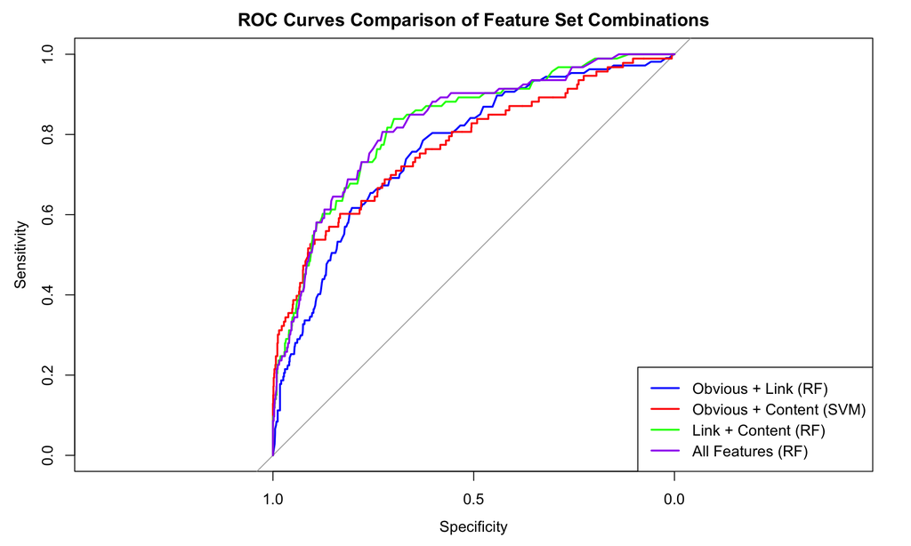

```r
# Create ROC plot for all combinations
plot(combo1_roc, col = "blue", main = "ROC Curves Comparison of Feature Set Combinations", lwd = 2)
lines(combo2_roc$specificities, combo2_roc$sensitivities, col = "red", lwd = 2)
lines(combo3_roc$specificities, combo3_roc$sensitivities, col = "green", lwd = 2)
lines(combo4_roc$specificities, combo4_roc$sensitivities, col = "purple", lwd = 2)
legend("bottomright", legend = c(
  paste("Obvious + Link (RF)"),
  paste("Obvious + Content (SVM)"),
  paste("Link + Content (RF)"),
  paste("All Features (RF)")
), col = c("blue", "red", "green", "purple"), lwd = 2)
```

```r
# Create comparison table
combo_comparison <- data.frame(
  Combination = c(
    "Obvious + Link",
    "Obvious + Content",
    "Link + Content",
    "All Features"
  ),
  Model = c(
    "Random Forest",
    "SVM (RBF)",
    "Random Forest",
    "Random Forest"
  ),
  AUC = c(
    round(auc(combo1_roc), 4),
    round(auc(combo2_roc), 4),
    round(auc(combo3_roc), 4),
    round(auc(combo4_roc), 4)
  ),
  Precision = c(
    round(combo1_precision, 4),
    round(combo2_precision, 4),
    round(combo3_precision, 4),
    round(combo4_precision, 4)
  ),
  Recall = c(
    round(combo1_recall, 4),
    round(combo2_recall, 4),
    round(combo3_recall, 4),
    round(combo4_recall, 4)
  ),
  F1 = c(
    round(combo1_f1, 4),
    round(combo2_f1, 4),
    round(combo3_f1, 4),
    round(combo4_f1, 4)
  )
)

combo_comparison %>%
  kable(caption = "Performance Comparison of Feature Set Combinations (Single Split)") %>%
  kable_styling(bootstrap_options = c("striped", "hover"))
```

Performance Comparison of Feature Set Combinations (Single Split)

| Combination | Model | AUC | Precision | Recall | F1 |
| --- | --- | --- | --- | --- | --- |
| Obvious + Link | Random Forest | 0.7662 | 0.3333 | 0.1402 | 0.1974 |
| Obvious + Content | SVM (RBF) | 0.7731 | 0.3000 | 0.3871 | 0.3380 |
| Link + Content | Random Forest | 0.8240 | 0.5152 | 0.1828 | 0.2698 |
| All Features | Random Forest | 0.8249 | 0.5714 | 0.2151 | 0.3125 |

#### Qualitative Analysis

- **Obvious + Link** This combination utilizes both simple site-level metrics and structural link data. The AUC of 0.7662 is modest, but the recall (0.1402) is very low, meaning the model misses many spam cases. While Random Forest handles link features well, the obvious features contribute little, and the overall spam detection is weak.
- **Obvious + Content** The SVM (RBF) model captures subtle, non-linear textual patterns in content. Although the precision (0.3000) is slightly lower, the recall improves significantly to 0.3871, resulting in the highest F1-score (0.3380) among all combinations. This suggests it’s relatively better at identifying spam correctly, even with fewer features.
- **Link + Content** This combination balances structural and content signals. Random Forest delivers the second-highest AUC (0.8240) and a better balance of precision (0.5152) and recall (0.1828) compared to previous sets. It shows robustness across spam strategies, although F1-score (0.2698) remains slightly behind SVM.
- **All Features** Using the full feature set yields the best overall AUC (0.8249) and the highest precision (0.5714). Recall (0.2151) improves over other Random Forest models, giving a strong F1-score of 0.3125. Although not the top in F1, this approach ensures stable, high-confidence predictions and is suitable when computational cost is acceptable.

⸻